# Ejercicio 6 - Estadistica Computacional

Cristóbal Marchant

2022-06-25

## 1. Prueba para contraste de media, con media poblacional y varianza conocida con una cola

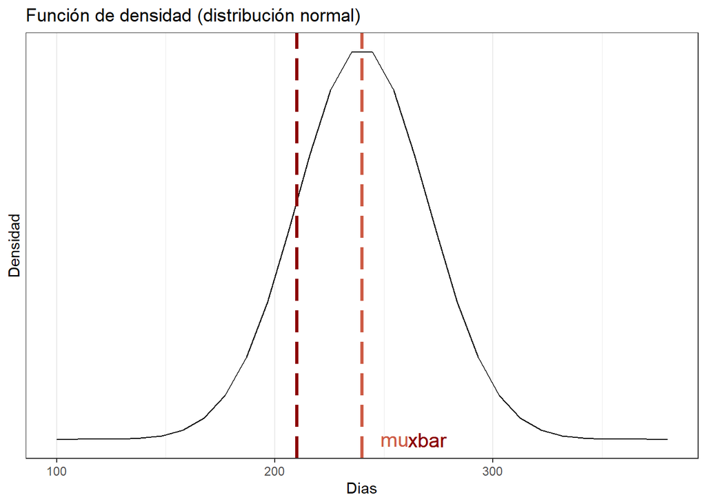

```r
library("ggplot2")

grafico_densidad = ggplot(data = data.frame(x = c(100, 380)), aes(x)) +
  stat_function(fun = dnorm, n = 30, args = list(mean =240, sd = 30)) + ylab("") +
  scale_y_continuous(breaks = NULL) + xlab("Dias") + ylab("Densidad") + ggtitle("Función de densidad (distribución normal)") + theme_bw() +
  geom_vline(xintercept = 210,cex=1.2,colour ="darkred",linetype="longdash") + geom_text(aes(x=270, label="xbar", y=0.0), colour ="darkred",size=5) + geom_vline(xintercept = 240,cex=1.2,colour ="coral3",linetype="longdash") + geom_text(aes(x=255, label="mu", y=0.00001), colour ="coral3",size=5)

grafico_densidad
```

Nuestra hipótesis nula, basándose en los datos señalados en el enunciado puede ser especificada como:

$$H_0:μ0 = 240 Días$$
$$H_0:μ0 < 240 Días$$
Si aplicamos la normalización para calcular z bajo una prueba de una cola, se tiene que:

```r
#Datos
mu=240
sigma = 15
muestra=rep(230,30)
x_bar=mean(muestra)
n= 30

#Normalización
z = (x_bar-mu)/(sigma/sqrt(n))

#Confianza
alfa = 0.05
confianza = 1-alfa

z_alfa = qnorm(1-alfa)

z
```

```
## [1] -3.651484
```

```r
z_alfa
```

```
## [1] 1.644854
```

El valor de z es -3.651484, mientras que zα es 1.644854. Esto implica que z es menor al intervalo de confianza, por lo que NO podemos rechazar Ha y rechazamos la H0.

Otra prueba de esto es aplicando la función el Z Test

```r
z=z.test(muestra,mu=mu,sigma.x=
sigma,conf.level =
confianza,alternative="less")
z
```

```
##
##  One-sample z-Test
##
## data:  muestra
## z = -3.6515, p-value = 0.0001304
## alternative hypothesis: true mean is less than 240
## 95 percent confidence interval:
##        NA 234.5046
## sample estimates:
## mean of x
##       230
```

Esto se puede Graficar de la siguiente manera

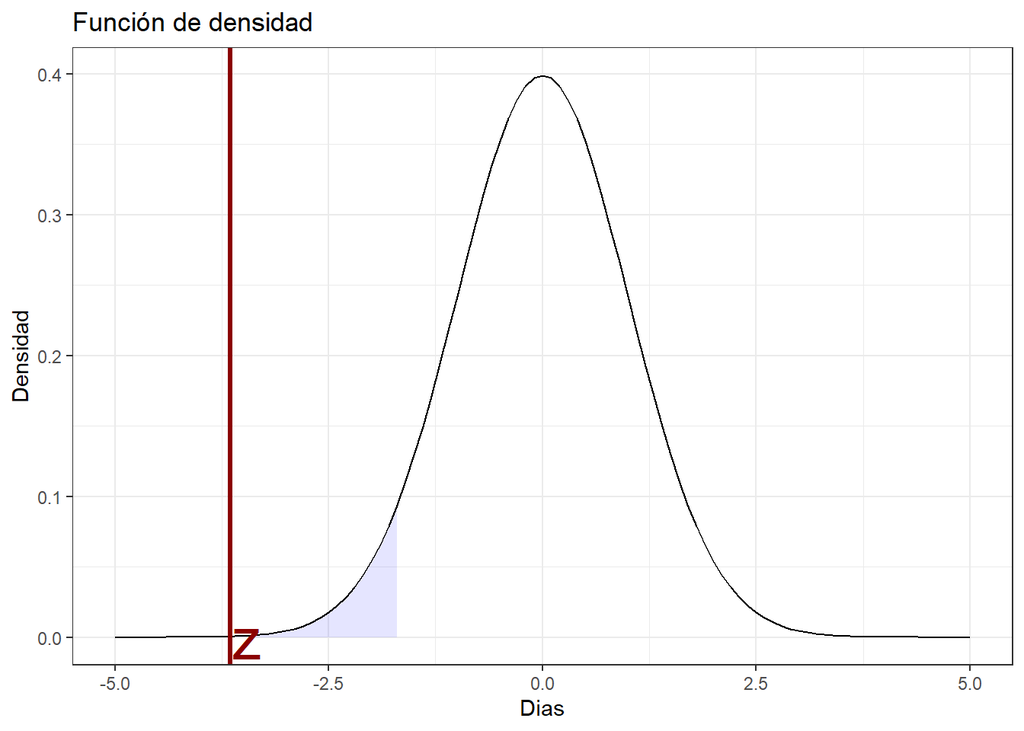

```r
dnorm_limit <- function(x) {
    y <- dnorm(x)
    y[x > -z_alfa] <- NA
    return(y)
}

grafico_densidad = ggplot(data.frame(x = c(-5, 5)), aes(x = x)) +
  stat_function(fun = dnorm_limit, geom = "area", fill = "blue", alpha = 0.1) +  stat_function(fun = dnorm) +
  xlab("Dias") + ylab("Densidad") + ggtitle("Función de densidad") +
  theme_bw() + geom_vline(xintercept = (x_bar-mu)/(sigma/sqrt(n)),cex=1.2,colour ="darkred") +
  geom_text(aes(x=(x_bar-mu)/(sigma/sqrt(n))+0.2, label="z", y=0.0), colour ="darkred",size=10)

plot(grafico_densidad)
```

## 2. Prueba para contraste de media, con media poblacional conocida y varianza desconocida con una cola.

Una empresa de videojuegos pública que los jugadores suelen jugar más de 900 minutos entre lunes y viernes. En una muestra de 30 jugadores se encontró que solo juegan en promedio durante 870 minutos. Suponga una desviación estándar de 50 minutos. Con un nivel de significancia del 0.05, ¿Que podemos concluir de esta afirmación?

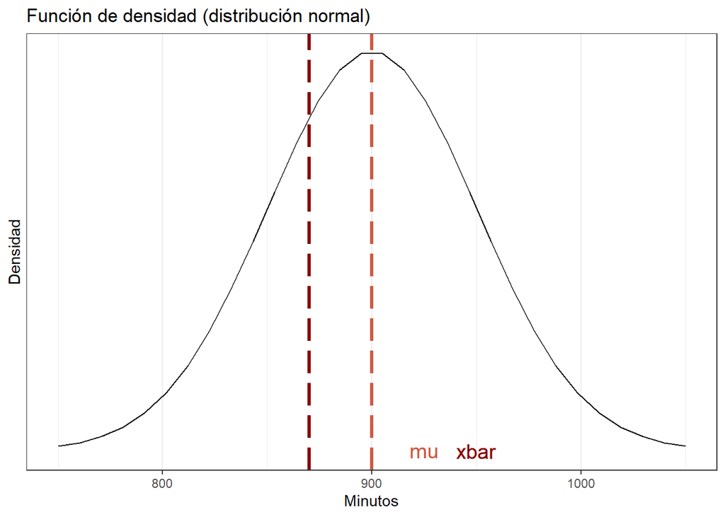

```r
grafico_densidad = ggplot(data = data.frame(x = c(750, 1050)), aes(x)) +
  stat_function(fun = dnorm, n = 30, args = list(mean =900, sd = 50)) + ylab("") +
  scale_y_continuous(breaks = NULL) + xlab("Minutos") + ylab("Densidad") + ggtitle("Función de densidad (distribución normal)") + theme_bw() +
  geom_vline(xintercept = 870,cex=1.2,colour ="darkred",linetype="longdash") + geom_text(aes(x=950, label="xbar", y=0.0), colour ="darkred",size=5) + geom_vline(xintercept = 900,cex=1.2,colour ="coral3",linetype="longdash") + geom_text(aes(x=925, label="mu", y=0.00001), colour ="coral3",size=5)

grafico_densidad
```

Nuestra hipótesis nula, basándose en los datos señalados en el enunciado puede ser especificada como:
$$H_0:μ0 = 900 minutos.$$
$$H_0:μa < 900 minutos.$$
Si aplicamos la normalización para calcular t bajo una prueba de una cola, nos queda que:

```r
#Datos
mu=900
s = 50
x_bar=870
n=30

#Normalización
t = (x_bar-mu)/(s/sqrt(n))

#Confianza
alfa = 0.05
confianza = 1-alfa

t_alfa = qt(1-alfa,df = n-1)

t
```

```
## [1] -3.286335
```

```r
t_alfa
```

```
## [1] 1.699127
```

El valor de t es -3.286335, mientras que tα es 1.699127. Esto implica que t es menor al intervalo de confianza, por lo que NO podemos rechazar Ha y rechazamos la H0.

Otra prueba de esto es aplicando la función el t Test

```r
x_bar=870
mu=900
sigma=50
n=30
set.seed(3)
muestra=rnorm(n,mean=x_bar,sigma)
t=t.test(muestra,mu=mu,conf.level=confianza,alternative="less")
t
```

```
##
##  One Sample t-test
##
## data:  muestra
## t = -5.6309, df = 29, p-value = 2.202e-06
## alternative hypothesis: true mean is less than 900
## 95 percent confidence interval:
##      -Inf 870.9103
## sample estimates:
## mean of x
##  858.3392
```

Esto se puede Graficar de la siguiente manera

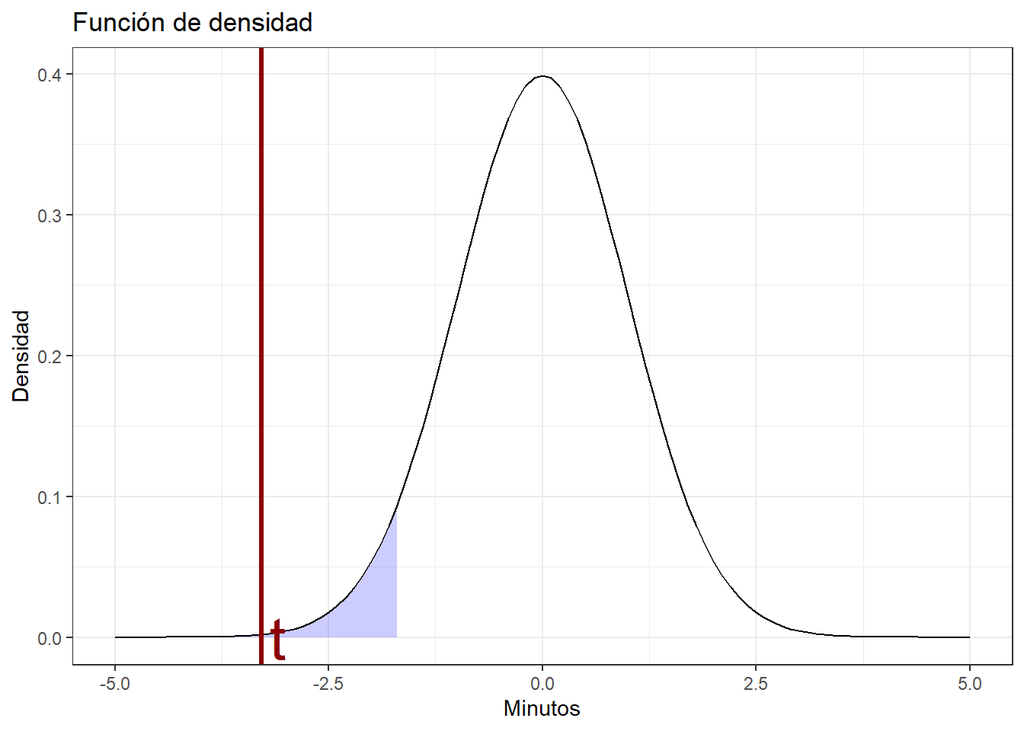

```r
dnorm_limit <- function(x) {
    y <- dnorm(x)
    y[x > -t_alfa] <- NA
    return(y)
}

# ggplot() with dummy data
grafico_densidad = ggplot(data.frame(x = c(-5, 5)), aes(x = x)) +
  stat_function(fun = dnorm_limit, geom = "area", fill = "blue", alpha = 0.2) +  stat_function(fun = dnorm) +
  xlab("Minutos") + ylab("Densidad") + ggtitle("Función de densidad") +
  theme_bw() + geom_vline(xintercept = (x_bar-mu)/(s/sqrt(n)),cex=1.2,colour ="darkred") +
  geom_text(aes(x=(x_bar-mu)/(s/sqrt(n))+0.2, label="t", y=0.0), colour ="darkred",size=10)

plot(grafico_densidad)
```

Una empresa del giro alimenticio desea determinar si el lote de una materia prima tiene o no una varianza poblacional mayor a 18 en su grado de endulzamiento. Se realiza un muestreo de 31 elementos y se obtiene una varianza muestral de 22,63; realizar la prueba de hipótesis con un nivel de significancia del 1%.

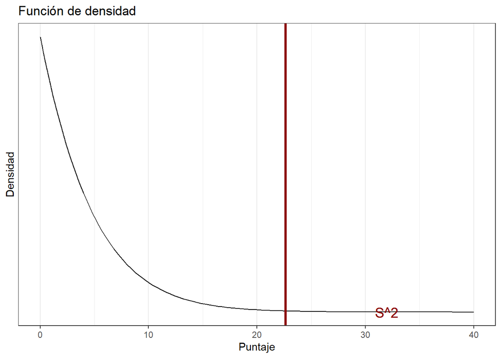

```r
grafico_densidad = ggplot(data = data.frame(x = c(0, 40)), aes(x)) +
  stat_function(fun = dchisq, n = 101, args = list(x =18, df = 30)) + ylab("") +
  scale_y_continuous(breaks = NULL) + xlab("Puntaje") + ylab("Densidad") + ggtitle("Función de densidad") + theme_bw() +
  geom_vline(xintercept = 22.63,cex=1.2,colour ="darkred") + geom_text(aes(x=32, label="S^2", y=0.0), colour ="darkred",size=5)

grafico_densidad
```

```r
#Datos
sigma2=18
n = 31
s2=22.63


#Normalización
chi = (n-1)*s2/(sigma2)

#Confianza
alfa = 0.01
confianza = 1-alfa

chi_alfa = qchisq(alfa,df = n-1,lower.tail = F) #Lower.tail se relaciona con <= de la hipótesis nula.

chi
```

```
## [1] 37.71667
```

```r
-chi_alfa
```

```
## [1] -50.89218
```

```r
chi_alfa
```

```
## [1] 50.89218
```

```r
#Creación de muestra artificial
set.seed(42)
datos=rnorm(31,sqrt(s2),n=n)

#Aplicación de test
chi = varTest(datos,sigma.squared=sigma2,alternative="greater")
print(chi)
```

```
##
## Results of Hypothesis Test
## --------------------------
##
## Null Hypothesis:                 variance = 18
##
## Alternative Hypothesis:          True variance is greater than 18
##
## Test Name:                       Chi-Squared Test on Variance
##
## Estimated Parameter(s):          variance = 34.56552
##
## Data:                            datos
##
## Test Statistic:                  Chi-Squared = 57.6092
##
## Test Statistic Parameter:        df = 30
##
## P-value:                         0.001775424
##
## 95% Confidence Interval:         LCL = 23.68963
##                                  UCL =      Inf
```

## 4. Bondad de ajuste Chi cuadrado

En un muestreo del iris de 80 alumnos de la usach, existe una proporción de ½ posee ojos marrones, 5/16 ojos verdes y el resto ojos verdes, ¿Existe alguna diferencia significativa entre las proporciones?

```r
data("iris")

iris = c(40/80, 25/80, 15/80)

sol = chisq.test(iris, p = c(1/2, 1/3, 1/6))
sol
```

```
##
##  Chi-squared test for given probabilities
##
## data:  iris
## X-squared = 0.0039062, df = 2, p-value = 0.998
```

## 5. Prueba de hipótesis en una proporción binomial, de una o dos colas.

El 64,8% de los jugadores de League of Legends está debajo de la división de oro. Se realiza una encuesta en una convención de video juego a 50 personas, de las cuales 32 están debajo de oro, ¿Que se puede concluir? considere un nivel de significancia del 5%.

Se tiene que

```r
x = 32
n = 50
h = 0.648
prop.test(x, n, p = h, alt="greater", correct =FALSE)
```

```
##
##  1-sample proportions test without continuity correction
##
## data:  x out of n, null probability h
## X-squared = 0.014029, df = 1, p-value = 0.5471
## alternative hypothesis: true p is greater than 0.648
## 95 percent confidence interval:
##  0.5238234 1.0000000
## sample estimates:
##    p
## 0.64
```

p al ser mayor o igual NO se rechaza H0.

## 6.Prueba de hipótesis en el que aplique la prueba del signo.

Una de empresa distribuidora de mangas desea saber la forma en la cual sus usuarios leen los mangas, para saber esto se reúne un grupo de 25 usuarios y les pregunta si prefieren leerlos de manera física o de manera digital, de estos 25 usuarios, 10 prefiere leerlos físicos mientras que el resto prefiere leerlos digitalmente. ¿es posible que si se lanza un sistema de lectura online este sea rentable? Considere una significancia del 5%.

```r
binom.test(15, 25, conf.level = 1-0.05)
```

```
##
##  Exact binomial test
##
## data:  15 and 25
## number of successes = 15, number of trials = 25, p-value = 0.4244
## alternative hypothesis: true probability of success is not equal to 0.5
## 95 percent confidence interval:
##  0.3866535 0.7887452
## sample estimates:
## probability of success
##                    0.6
```

## 7. Prueba de hipótesis en el que aplique la prueba de Wilcoxon para una muestra.

Luego del cambio de meta actual, algunos de los los campeones ADC de League of Legends tuvieron un cambio en su winrate, es por esto que podemos observar la siguiente tabla:

```r
df= data.frame(
  "campeón" = c("Ezreal", "Jhin", "Kai'sa", "Zeri", "Lucian", "Twitch", "Samira", "Vayne", "Jinx", "Draven", "Caitlyn", "Miss Fortune", "Ashe"),
  "WinRate" = c(49.26, 51.55, 49.12, 49.94, 48.90, 51.88, 49.98, 50.36, 48.48, 50.49, 47.91, 51.31, 51.85)
)
df
```

```
##         campeón WinRate
## 1        Ezreal   49.26
## 2          Jhin   51.55
## 3        Kai'sa   49.12
## 4          Zeri   49.94
## 5        Lucian   48.90
## 6        Twitch   51.88
## 7        Samira   49.98
## 8         Vayne   50.36
## 9          Jinx   48.48
## 10       Draven   50.49
## 11      Caitlyn   47.91
## 12 Miss Fortune   51.31
## 13         Ashe   51.85
```

Para este ejemplo, buscamos saber si el rol de ADC dentro del juego es rentable, es decir, que posea un winrate superior al 50%, considere una significancia del 5%.

```r
wilcox.test(df$WinRate, mu = 50, conf.int = 1-0.05)
```

```
##
##  Wilcoxon signed rank exact test
##
## data:  df$WinRate
## V = 48, p-value = 0.8926
## alternative hypothesis: true location is not equal to 50
## 95 percent confidence interval:
##  49.200 50.915
## sample estimates:
## (pseudo)median
##          50.15
```